[output not shown]

# Analiza zbioru danych dotyczaca Irysow

## Ogolny opis danych uzytych do analizy

Ponizsza analiza zawiera informacje o trzech gatunkach irysów: Iris setosa, Iris versicolor, i Iris virginica.

Analiza obejmują pomiary czterech cech dla kazdego z gatunku Irysow: długość i szerokość działki kielicha oraz długość i szerokość płatka, a wartości pomiarów są podane w centymetrach.

Analiza składa się z 150 próbek, po 50 dla każdego gatunku, i jest szeroko stosowany jako podstawowy zbiór danych do testowania algorytmów klasyfikacji oraz w nauce o danych i uczeniu maszynowym.

Ten zbior danych posiada nastepujace kolumny, ktore pomagaja w latwiejszej analizie zebranych informacji:

- **długość kielicha (sepal length)** - Długość kielicha w cm
- **szerokość kielicha (sepal width)** - Szerokość kielicha w cm
- **długość płatka (petal length)** - Długość płatka w cm
- **szerokość płatka (petal width)** - Szerokość płatka w cm
- **klasa (class)** - Klsa irysa (setosa, versicolor, virginica)

|  | długość kielicha (sepal length) | szerokość kielicha (sepal width) | długość płatka (petal length) | szerokość płatka (petal width) | klasa (class) |
| --- | --- | --- | --- | --- | --- |
| 72 | 6.3 | 2.5 | 4.9 | 1.5 | Iris-versicolor |
| 112 | 6.8 | 3.0 | 5.5 | 2.1 | Iris-virginica |
| 132 | 6.4 | 2.8 | 5.6 | 2.2 | Iris-virginica |
| 88 | 5.6 | 3.0 | 4.1 | 1.3 | Iris-versicolor |
| 37 | 4.9 | 3.1 | 1.5 | 0.1 | Iris-setosa |
| 138 | 6.0 | 3.0 | 4.8 | 1.8 | Iris-virginica |
| 87 | 6.3 | 2.3 | 4.4 | 1.3 | Iris-versicolor |
| 42 | 4.4 | 3.2 | 1.3 | 0.2 | Iris-setosa |
| 8 | 4.4 | 2.9 | 1.4 | 0.2 | Iris-setosa |
| 90 | 5.5 | 2.6 | 4.4 | 1.2 | Iris-versicolor |

## Zobaczmy czy napewno kazda z kolumn nie ma brakujacych wartosci

```
długość kielicha (sepal length)     0
szerokość kielicha (sepal width)    0
długość płatka (petal length)       0
szerokość płatka (petal width)      0
klasa (class)                       0
dtype: int64
```

## Jaki widac nie brakuje nam zardnych wartosci ale przedstawmy to w bardziej przyjemny sposob

|  | Cecha | Brakujace wartosci |
| --- | --- | --- |
| 0 | długość kielicha (sepal length) | 0 |
| 1 | szerokość kielicha (sepal width) | 0 |
| 2 | długość płatka (petal length) | 0 |
| 3 | szerokość płatka (petal width) | 0 |
| 4 | klasa (class) | 0 |

Brak niekompletnosci zerbanych informacji o Irysach umozliwiaja nam dokladniejsza analize danych. Przez to ze dane zostaly zebrane kompetentnie, nie musimy ingerowac w uzupelnianie ich aby dokonac dokladnej analizy.

## Teraz mozemy sprawdzic z iloma doklanie gatunakami Irysa przyjdzie nam pracowac i ile kazdy posiada wartosci

|  | klasa (class) | count |
| --- | --- | --- |
| 0 | Iris-setosa | 50 |
| 1 | Iris-versicolor | 50 |
| 2 | Iris-virginica | 50 |

## Podsumujmy sobie tez wszystkie kolumny numeryczne

|  | długość kielicha (sepal length) | szerokość kielicha (sepal width) | długość płatka (petal length) | szerokość płatka (petal width) |
| --- | --- | --- | --- | --- |
| count | 150.00 | 150.00 | 150.00 | 150.00 |
| mean | 5.84 | 3.05 | 3.76 | 1.20 |
| std | 0.83 | 0.43 | 1.76 | 0.76 |
| min | 4.30 | 2.00 | 1.00 | 0.10 |
| 25% | 5.10 | 2.80 | 1.60 | 0.30 |
| 50% | 5.80 | 3.00 | 4.35 | 1.30 |
| 75% | 6.40 | 3.30 | 5.10 | 1.80 |
| max | 7.90 | 4.40 | 6.90 | 2.50 |

## Sparwdzimy liczbe unikatowych wartosci kazedej z cech

|  | index | 0 |
| --- | --- | --- |
| 0 | długość kielicha (sepal length) | 35 |
| 1 | szerokość kielicha (sepal width) | 23 |
| 2 | długość płatka (petal length) | 43 |
| 3 | szerokość płatka (petal width) | 22 |
| 4 | klasa (class) | 3 |

Jak widac roznorodnosc cech jest bardzo urozmaicona.

Po wstepnej analizie jestesmy w stanie stwierdzic ze nie brakuje zadnych wartosci, co tworzy ten zior danych kompletnym. Ale czy przy tak urozmaiconym zestawie informocji, nie ma zadnych powtarzaja sie zadne wratosci? Sprawdzmy to.

|  | długość kielicha (sepal length) | szerokość kielicha (sepal width) | długość płatka (petal length) | szerokość płatka (petal width) | klasa (class) |
| --- | --- | --- | --- | --- | --- |
| 34 | 4.9 | 3.1 | 1.5 | 0.1 | Iris-setosa |
| 37 | 4.9 | 3.1 | 1.5 | 0.1 | Iris-setosa |
| 142 | 5.8 | 2.7 | 5.1 | 1.9 | Iris-virginica |

Jak widac nawet przy tak kompletnym zbiorze informacji, jestemy w stanie uznac ze jendak wystapily w nim duplikaty.

## Zrobmy porownanie 3 rodzajow Irysow

|  | klasa (class) | długość kielicha (sepal length) min | długość kielicha (sepal length) max | długość kielicha (sepal length) mean | długość kielicha (sepal length) median | szerokość kielicha (sepal width) min | szerokość kielicha (sepal width) max | szerokość kielicha (sepal width) mean | szerokość kielicha (sepal width) median | długość płatka (petal length) min | długość płatka (petal length) max | długość płatka (petal length) mean | długość płatka (petal length) median | szerokość płatka (petal width) min | szerokość płatka (petal width) max | szerokość płatka (petal width) mean | szerokość płatka (petal width) median |
| --- | --- | --- | --- | --- | --- | --- | --- | --- | --- | --- | --- | --- | --- | --- | --- | --- | --- |
| 0 | Iris-setosa | 4.3 | 5.8 | 5.006 | 5.0 | 2.3 | 4.4 | 3.418 | 3.4 | 1.0 | 1.9 | 1.464 | 1.50 | 0.1 | 0.6 | 0.244 | 0.2 |
| 1 | Iris-versicolor | 4.9 | 7.0 | 5.936 | 5.9 | 2.0 | 3.4 | 2.770 | 2.8 | 3.0 | 5.1 | 4.260 | 4.35 | 1.0 | 1.8 | 1.326 | 1.3 |
| 2 | Iris-virginica | 4.9 | 7.9 | 6.588 | 6.5 | 2.2 | 3.8 | 2.974 | 3.0 | 4.5 | 6.9 | 5.552 | 5.55 | 1.4 | 2.5 | 2.026 | 2.0 |

Po porownaniu wszytskich trzech gatunkow Irysow, jestesmy w stanie stwierdzic ze Irys-Virginica jest najwiekszy, na drugim miejscu jest Irys-Versicolor a najmniejszy jest Iris-Setosa.

## Podsumowanie

- Dane wykorzystane do analizy nie posiadaja brakow
- Mimo tak kompletnych danych pojawiaja sie duplikaty
- Gatunki Irysow uzyte do analizy roznia sie rozmiarami
- Wieksza ilosc danych podanych w tym zbiorze to dane numeryczne

## Poniewaz dane sa kompletne, mozemy sprobowac zwizualizowac teraz cechy charakterystyczne dla kazdego rodzaju Irysa na pare roznych sposobow

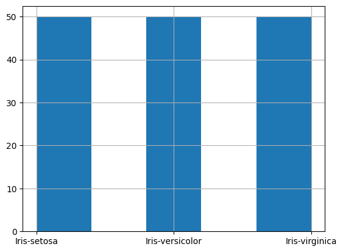

## Jak widzimy rezultat jest niezbyt czytelny wiec zwizualizujemy kazda z rodzaji Irysow w kilka roznych sposobow

# Zacznijmy od Iris-setosa

### Oto wykres slupkowy przedstawiajacy wartosci dla cech gatunku Irys-Setosa

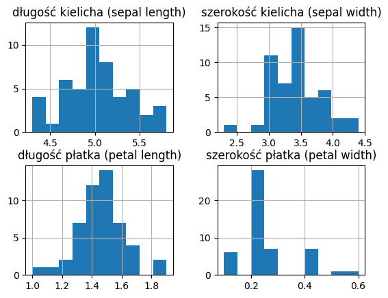

### Treaz uzyjmy wykresow Pudelkowych do wyszukania cech odstajacych

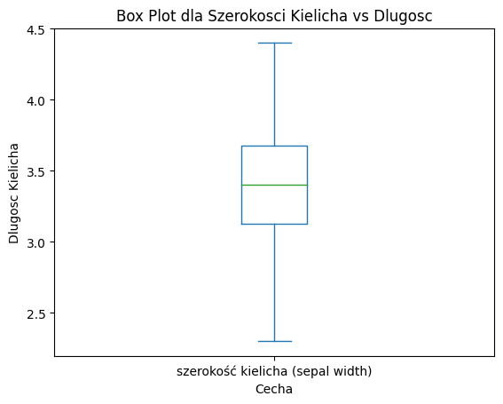

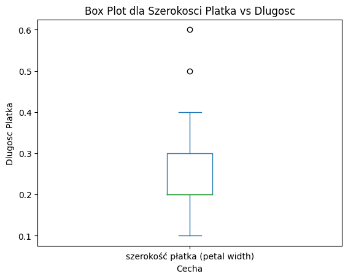

### Teraz uzyjmy Macierzy Korelacji aby zwizualizowac sobie zaleznosci miedzy cechami tego gatunku Irysa

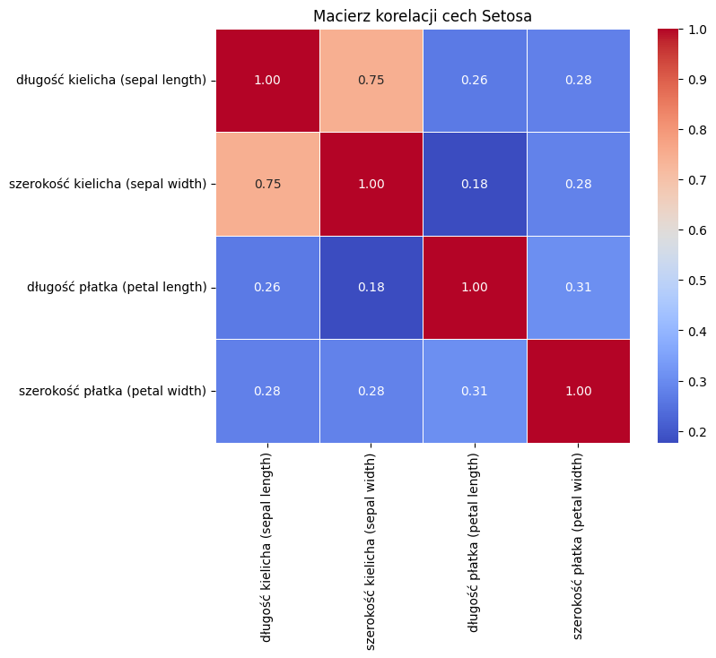

|  | długość kielicha (sepal length) | szerokość kielicha (sepal width) | długość płatka (petal length) | szerokość płatka (petal width) |
| --- | --- | --- | --- | --- |
| count | 50.00 | 50.00 | 50.00 | 50.00 |
| mean | 5.01 | 3.42 | 1.46 | 0.24 |
| std | 0.35 | 0.38 | 0.17 | 0.11 |
| min | 4.30 | 2.30 | 1.00 | 0.10 |
| 25% | 4.80 | 3.12 | 1.40 | 0.20 |
| 50% | 5.00 | 3.40 | 1.50 | 0.20 |
| 75% | 5.20 | 3.68 | 1.58 | 0.30 |
| max | 5.80 | 4.40 | 1.90 | 0.60 |

Jak widac w gatunku Iris-setosa im dluzszy kielich tym szerszy jest jego kielich. Aczkolwiek dlugosc i szerokosc kielicha nie ma wplywy na szerokosc i dlugosc platka.

# Nasetepnie Iris-versicolor

### Wykres slupkowy dla Gatunku Iris-versicolor

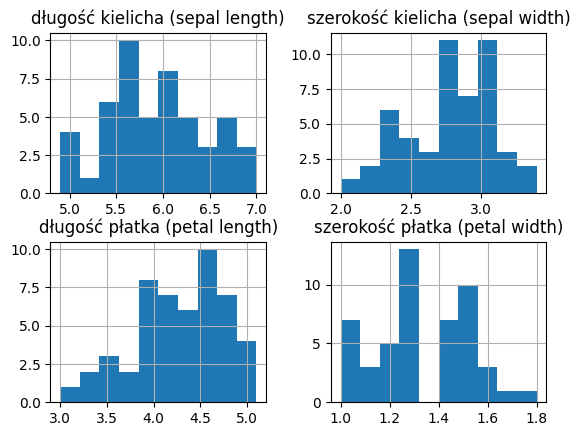

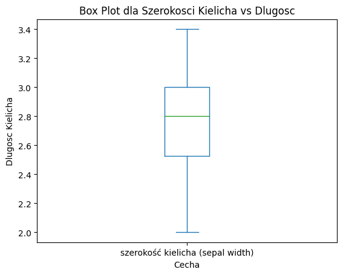

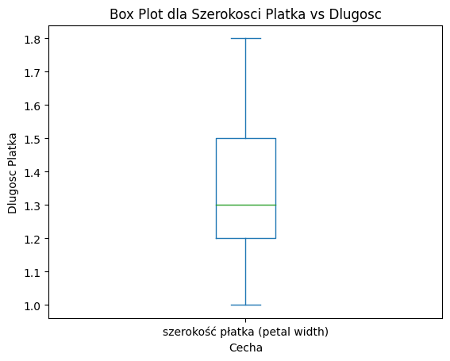

# Macierz korelacji

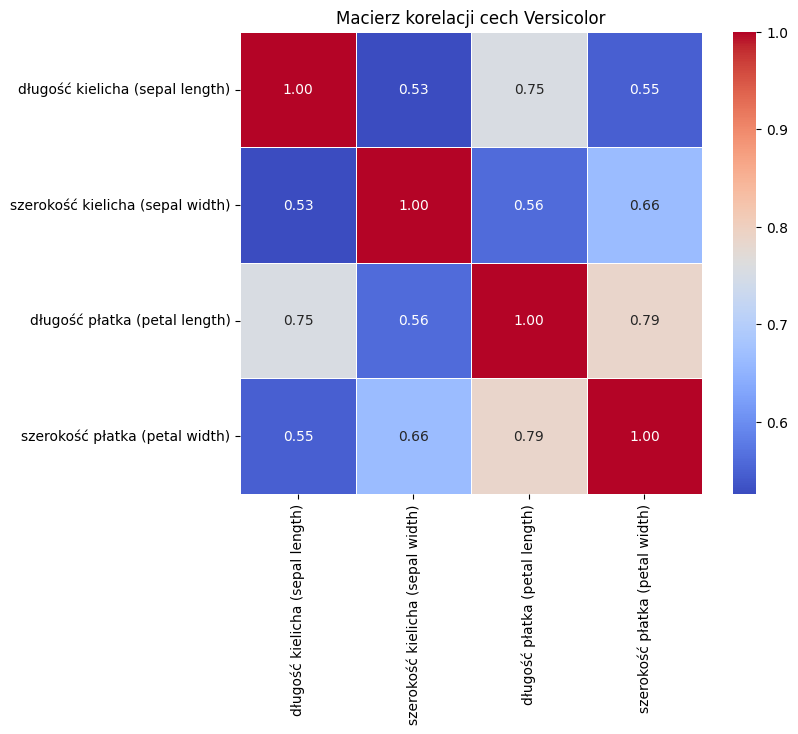

|  | długość kielicha (sepal length) | szerokość kielicha (sepal width) | długość płatka (petal length) | szerokość płatka (petal width) |
| --- | --- | --- | --- | --- |
| count | 50.00 | 50.00 | 50.00 | 50.00 |
| mean | 5.94 | 2.77 | 4.26 | 1.33 |
| std | 0.52 | 0.31 | 0.47 | 0.20 |
| min | 4.90 | 2.00 | 3.00 | 1.00 |
| 25% | 5.60 | 2.52 | 4.00 | 1.20 |
| 50% | 5.90 | 2.80 | 4.35 | 1.30 |
| 75% | 6.30 | 3.00 | 4.60 | 1.50 |
| max | 7.00 | 3.40 | 5.10 | 1.80 |

W gatunku Iris-versicolor mamy juz duza korelacje miedzy dlugiscia kielicha i jego platka oraz szerokscia platka. Wiec sadze ze im dluzszy kielich tym szerokosc i dlugosc platka tez sie zwiekszy.

# I na koniec Iris-virginica

## Wykres Slupkowy

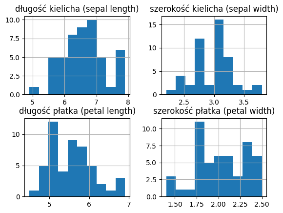

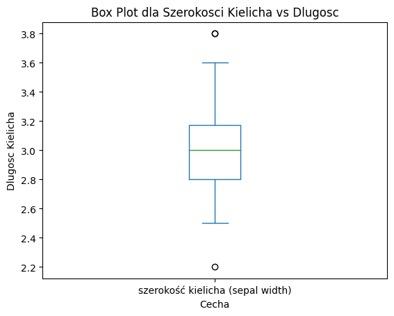

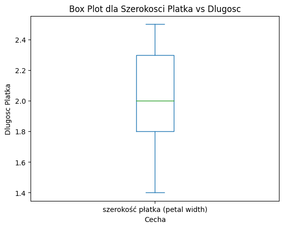

# Macierz Korelacji

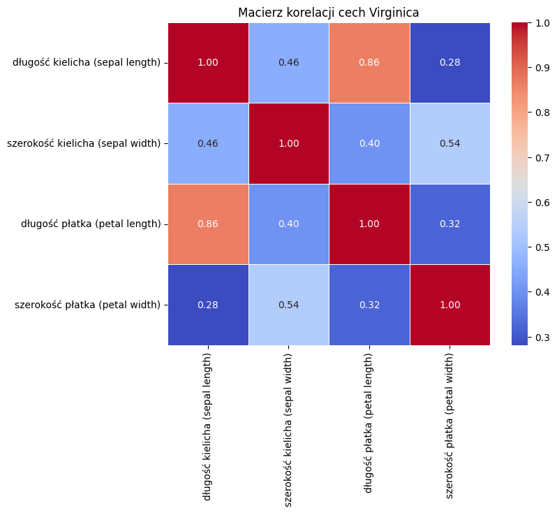

|  | długość kielicha (sepal length) | szerokość kielicha (sepal width) | długość płatka (petal length) | szerokość płatka (petal width) |
| --- | --- | --- | --- | --- |
| count | 50.00 | 50.00 | 50.00 | 50.00 |
| mean | 6.59 | 2.97 | 5.55 | 2.03 |
| std | 0.64 | 0.32 | 0.55 | 0.27 |
| min | 4.90 | 2.20 | 4.50 | 1.40 |
| 25% | 6.22 | 2.80 | 5.10 | 1.80 |
| 50% | 6.50 | 3.00 | 5.55 | 2.00 |
| 75% | 6.90 | 3.18 | 5.88 | 2.30 |
| max | 7.90 | 3.80 | 6.90 | 2.50 |

W gatunku Iris-virginica duza zaleznosc ma dlugosc kielicha na dlugosc platka. To sugeruje ze im dluzszy kielich tym dluzszy bedzie jego platek.

# Po podsumowaniu kazdego z gatunkow Irysow porownajmu sobie je wszystkie miedzy soba

### Zacznijmy od porownania Macierzy Korelacji miedzy cechami Irysow

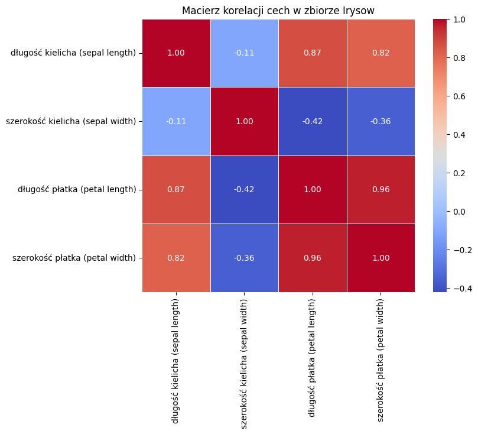

# Podsumowanie

- Dlugosc platka oraz jesgo szerokosc maja bardzo wysoki poziom korelacji. Co oznacza ze dluzszy platek bedzie posiadal szerszy platek.
- Dlugosc kielicha ma rowniesz znaczenie co do dlugosci i szerokosci platka. Im dluzszy kielich tym platki beda dluzsze orasz szersze.
- Rowniez widac tez ze posiadamy odwrotna korelacje miedzy szerokoscia kileicha a dlugoscia platka. To sugeruje ze kiedy kwiaty z szerszym kielichem posiadaja krotsze platki.

# Rozlozenie zmiennych miedzy wszystkimi gatunkami Irysow

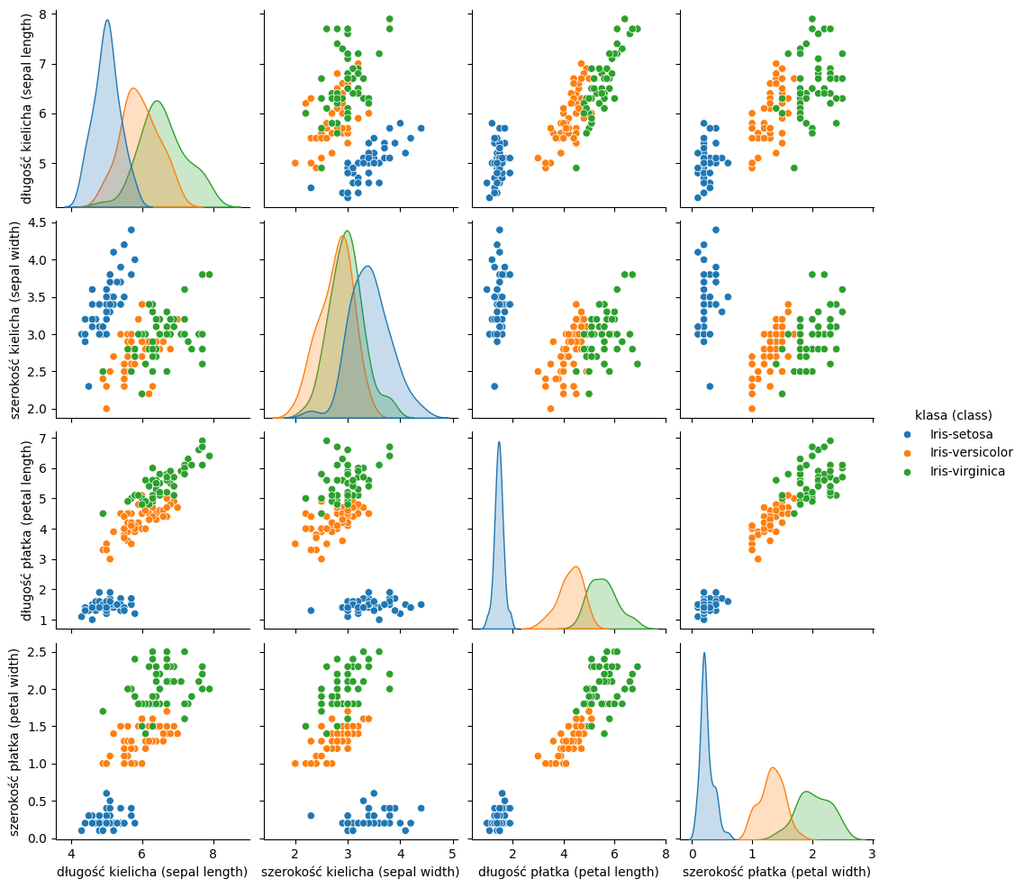

# Podsumowanie

- Analiza wykresow pokazuje ze gatunek Iris-setosa jest najbardziej odseparowanym gatunkiem.
- Jesli chodzi o dwa pozostale gatunki, wykresy ukazuja ze czesto posiadaja nachodzace na siebie wartosci co sugeruje ich podobienscto. Aczkolwiek bylibysmy w satnie je rozronic po roznych platkach.

# Wyszukiwanie wartosci odstajacych za pomoca wykresow pudelkowych

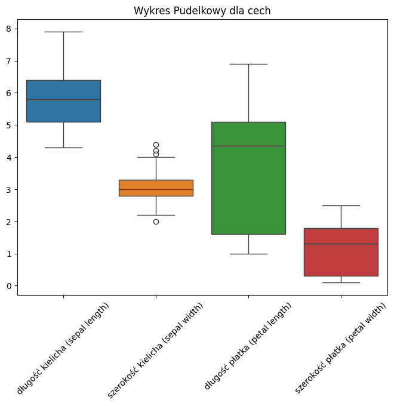

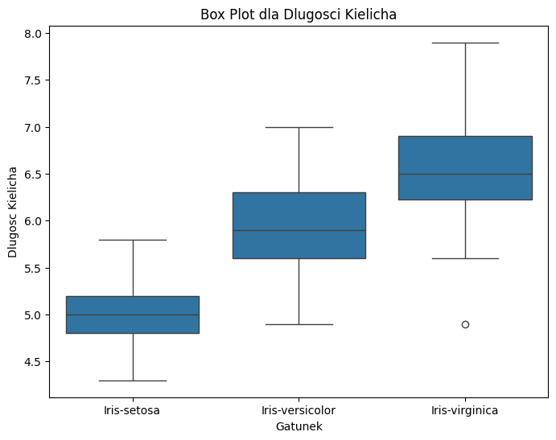

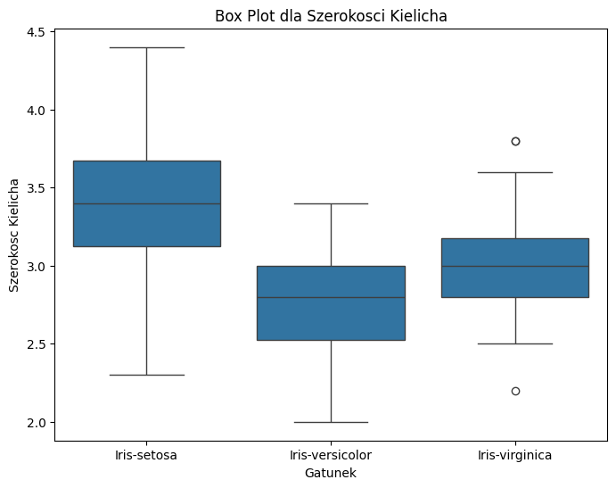

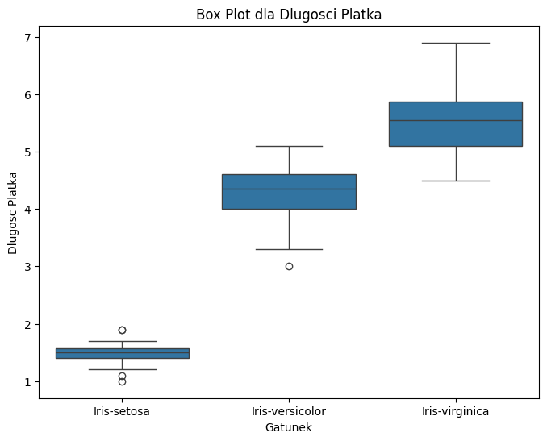

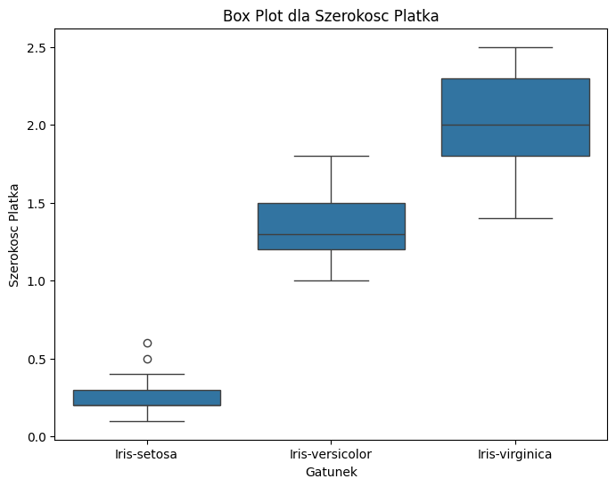

# Podsumowanie Wykresow Pudelkowych

- Jak widac z wykresow wartosci odstajace nie sa duze. Zdazaja sie wyjatki w kazdym z Gatunkow.
- Najwiecej wartosci odstajacych posiada gatunek Iris-setosa, jesli chodzi o jego dlugosc i szerokosc platka.

# Wioski

## Biorac pod uwage wszystkie zebrane dane jestesmy w stanie stwierdzic ze:

- Dane zawieraja informacje o trzech roznych rodzajach Irysow. Porownywane sa dlugosci oraz szerokosci ich kielichow zarownie jak ich platkow.
- Rodzaj Iryrsa Setosa jest najmniejsza odmiana kwatiu ze srednia dlugoscia 5cm i szerokoszcia 3.4cm.
- Drugim wielkoscia jest rodzaj Versicolor srednia dlugosc tego rodzaju wynosi 6cm a jej szerokosc 3 cm.
- A najwiekszym z nich jest Virginica. Dlugosc tego rodzaju wynsi 6.5cm z szerokoscia 3cm.
- Kiedy kwiat posiada dluzszy kielich, jego platek bedzie dluzszy a jego platek bedzie szerszy.
- Gatunek Iris-setosa najbardziej rozni sie od pozostalych garonkow.
- Mimo tego ze Iris-versicolor oraz Iris-virginica sa bardzo do siebie podobne, mozemy je rozroznic poprzez ich platki.

[output not shown]